# Mass Shooting Report

Arianna Collett

05/15/2021

## Summary Information

Link to the original data source: http://www.shootingtracker.com/

## Summary Table

The following table describes the average number of lives lost per city in descending order.

The Average Number of Lives Lost Per City

| City Name | Avg Number of Lives Lost |
| --- | --- |
| Pompano Beach (Parkland) | 17.0000000 |
| Thousand Oaks | 13.0000000 |
| Pittsburgh | 11.0000000 |
| Santa Fe | 10.0000000 |
| Annapolis | 5.0000000 |
| Columbia | 5.0000000 |
| Melcroft | 5.0000000 |
| Paintsville | 5.0000000 |
| Ponder | 5.0000000 |
| Robstown | 5.0000000 |
| Wilmington | 5.0000000 |
| Aberdeen | 4.0000000 |
| Antioch | 4.0000000 |
| Asheville | 4.0000000 |
| Clearlake | 4.0000000 |
| Gallup | 4.0000000 |
| Reading | 4.0000000 |
| Saint Charles | 4.0000000 |
| Silver Spring | 4.0000000 |
| Taft | 4.0000000 |
| Bakersfield | 3.5000000 |
| Baton Rouge | 3.0000000 |
| Dunn | 3.0000000 |
| Fort Wayne | 3.0000000 |
| Globe | 3.0000000 |
| Lake Worth (Lantana) | 3.0000000 |
| Little Rock | 3.0000000 |
| Stockton | 3.0000000 |
| Tallahassee | 3.0000000 |
| Timmonsville | 3.0000000 |

[output cut: 166 more lines]

This table shows us that the most deathly city by far is Pompano Beach with an average of 17 lives lost throughout 2018. Additionally, it shows us that there were only 4 cities with a average death count of 10 or above and that most cites did not even have more than 5 lives lost on average throughout 2018.

## Description of a particular incident

This particular incident is the most deadly shooting of 2018. Occurring on February 14, 2018 in Pompano Beach (Parkland), 17 individuals lost their lives and 17 were injured. This tragedy occurred at Stoneman Douglas High School and was the catalyst for students all across America joining together in an effort to protect their schools from gun violence in the future.

Link to more information: https://en.wikipedia.org/wiki/Stoneman_Douglas_High_School_shooting

## An interactive map

[interactive chart not shown]

This interactive map shows each of the shooting incidents with the radius of their circle being the impact on the lives of those who were in involved. The map shows that the eastern side of the united states is significantly more impacted by gun violence than the western side. Additionally, when clicking on the circles with the largest radius it is clear that the largest shootings are often in big cites not small ones.

## A plot of your choice

Question about plot: Which states have the highest numbers of shootings?

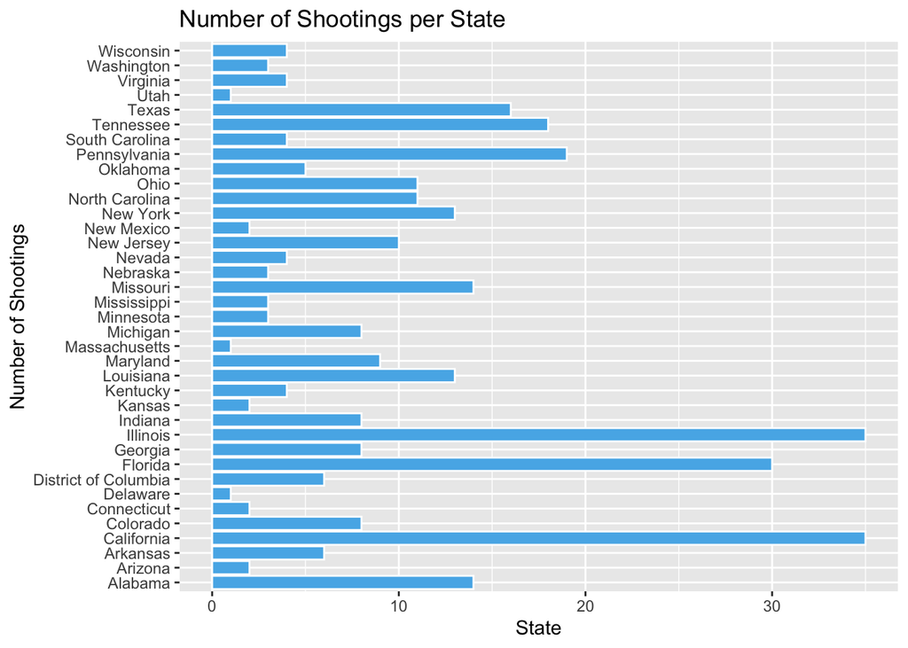